# Data Exploration with Python and Jupyter

Basic usage of the Pandas library to download a dataset, explore its contents, clean up missing or invalid data, filter the data according to different criteria, and plot visualizations of the data.

- [Part 1: Python and Jupyter](https://ssciwr.github.io/jupyter-data-exploration)
- [Part 2: Pandas with toy data](https://ssciwr.github.io/jupyter-data-exploration/pandas-toy-data.slides.html)
- **Part 3: Pandas with real data**

*Press `Spacebar` to go to the next slide (or `?` to see all navigation shortcuts)*

# Let's download some real data

For some reason, the London Fire Brigade provides a public spreadsheet of all animal rescue incidents since 2009:

https://data.london.gov.uk/dataset/animal-rescue-incidents-attended-by-lfb

They provide a link to the dataset in csv (comma-delimited) format

```python
# import the Pandas library & matplotlib for plotting

import pandas as pd
import matplotlib.pyplot as plt
```

```python
# download a csv file with some data and convert it to a DataFrame
url = "https://data.london.gov.uk/download/animal-rescue-incidents-attended-by-lfb/f43b485e-fb35-419c-aa7a-fa75676e5835/Animal%20Rescue%20incidents%20attended%20by%20LFB%20from%20Jan%202009.csv"
df = pd.read_csv(url, encoding="unicode_escape")
```

# Sidenote

You may be wondering what this `encoding='unicode_escape'` parameter is for, and how did I know it needed to be there?

Well, I first tried `pd.read_csv(url)` and got this:

```
---------------------------------------------------------------------------
UnicodeDecodeError                        Traceback (most recent call last)
/tmp/ipykernel_514329/874975015.py in <module>
----> 1 pd.read_csv(url)

~/.pyenv/versions/3.9.4/lib/python3.9/site-packages/pandas/io/parsers.py in read_csv(filepath_or_buffer, sep, delimiter, header, names, index_col, usecols, squeeze, prefix, mangle_dupe_cols, dtype, engine, converters, true_values, false_values, skipinitialspace, skiprows, skipfooter, nrows, na_values, keep_default_na, na_filter, verbose, skip_blank_lines, parse_dates, infer_datetime_format, keep_date_col, date_parser, dayfirst, cache_dates, iterator, chunksize, compression, thousands, decimal, lineterminator, quotechar, quoting, doublequote, escapechar, comment, encoding, dialect, error_bad_lines, warn_bad_lines, delim_whitespace, low_memory, memory_map, float_precision, storage_options)
    608     kwds.update(kwds_defaults)
    609
--> 610     return _read(filepath_or_buffer, kwds)
    611
    612

~/.pyenv/versions/3.9.4/lib/python3.9/site-packages/pandas/io/parsers.py in _read(filepath_or_buffer, kwds)
    460
    461     # Create the parser.
--> 462     parser = TextFileReader(filepath_or_buffer, **kwds)
    463
    464     if chunksize or iterator:

~/.pyenv/versions/3.9.4/lib/python3.9/site-packages/pandas/io/parsers.py in __init__(self, f, engine, **kwds)
    817             self.options["has_index_names"] = kwds["has_index_names"]
    818
--> 819         self._engine = self._make_engine(self.engine)
    820
    821     def close(self):

~/.pyenv/versions/3.9.4/lib/python3.9/site-packages/pandas/io/parsers.py in _make_engine(self, engine)
   1048             )
   1049         # error: Too many arguments for "ParserBase"
-> 1050         return mapping[engine](self.f, **self.options)  # type: ignore[call-arg]
   1051
   1052     def _failover_to_python(self):

~/.pyenv/versions/3.9.4/lib/python3.9/site-packages/pandas/io/parsers.py in __init__(self, src, **kwds)
   1896
   1897         try:
-> 1898             self._reader = parsers.TextReader(self.handles.handle, **kwds)
   1899         except Exception:
   1900             self.handles.close()

pandas/_libs/parsers.pyx in pandas._libs.parsers.TextReader.__cinit__()

pandas/_libs/parsers.pyx in pandas._libs.parsers.TextReader._get_header()

pandas/_libs/parsers.pyx in pandas._libs.parsers.TextReader._tokenize_rows()

pandas/_libs/parsers.pyx in pandas._libs.parsers.raise_parser_error()

UnicodeDecodeError: 'utf-8' codec can't decode byte 0xa3 in position 105: invalid start byte
```

## Suggested workflow / philosophy

- you want to do something
  - if you know / have a guess which function to use, look at its docstring: `?function_name`
  - if you don't have any idea what to try, google `how do I ... in pandas`
  - if in doubt, just try something!
- if you get an error, copy & paste the last bit into google (along with `funtion_name` and/or `pandas`)
  - don't be intimidated by the long and apparently nonsensical error messages
  - almost certainly someone else has had this exact problem
  - almost certainly the solution is waiting for you
- look for a stackoverflow answer with many up-votes
  - ignore the green tick, this just means the person asking the question liked the answer
  - typically an answer with many up-votes is a better option
  - more recent answers can also be better: sometimes a library has changed since an older answer was written

(For anyone who wasn't already doing this, that may be the most useful thing in this course)

# Display the DataFrame

```python
df
```

|  | IncidentNumber | DateTimeOfCall | CalYear | FinYear | TypeOfIncident | PumpCount | PumpHoursTotal | HourlyNotionalCost(£) | IncidentNotionalCost(£) | FinalDescription | ... | UPRN | Street | USRN | PostcodeDistrict | Easting_m | Northing_m | Easting_rounded | Northing_rounded | Latitude | Longitude |
| --- | --- | --- | --- | --- | --- | --- | --- | --- | --- | --- | --- | --- | --- | --- | --- | --- | --- | --- | --- | --- | --- |
| 0 | 139091 | 01/01/2009 03:01 | 2009 | 2008/09 | Special Service | 1.0 | 2.0 | 255 | 510.0 | Redacted | ... | NaN | Waddington Way | 20500146.0 | SE19 | NaN | NaN | 532350 | 170050 | NaN | NaN |
| 1 | 275091 | 01/01/2009 08:51 | 2009 | 2008/09 | Special Service | 1.0 | 1.0 | 255 | 255.0 | Redacted | ... | NaN | Grasmere Road | NaN | SE25 | 534785.0 | 167546.0 | 534750 | 167550 | 51.390954 | -0.064167 |
| 2 | 2075091 | 04/01/2009 10:07 | 2009 | 2008/09 | Special Service | 1.0 | 1.0 | 255 | 255.0 | Redacted | ... | NaN | Mill Lane | NaN | SM5 | 528041.0 | 164923.0 | 528050 | 164950 | 51.368941 | -0.161985 |
| 3 | 2872091 | 05/01/2009 12:27 | 2009 | 2008/09 | Special Service | 1.0 | 1.0 | 255 | 255.0 | Redacted | ... | 1.000000e+11 | Park Lane | 21401484.0 | UB9 | 504689.0 | 190685.0 | 504650 | 190650 | 51.605283 | -0.489684 |
| 4 | 3553091 | 06/01/2009 15:23 | 2009 | 2008/09 | Special Service | 1.0 | 1.0 | 255 | 255.0 | Redacted | ... | NaN | Swindon Lane | 21300122.0 | RM3 | NaN | NaN | 554650 | 192350 | NaN | NaN |
| ... | ... | ... | ... | ... | ... | ... | ... | ... | ... | ... | ... | ... | ... | ... | ... | ... | ... | ... | ... | ... | ... |
| 8485 | 077969-31052022 | 31/05/2022 06:18 | 2022 | 2022/23 | Special Service | 1.0 | 1.0 | 364 | 364.0 | FOX STUCK IN NETTING IN FOOTBALL PITCH RSPCA ... | ... | 6.070003e+06 | SHELMERDINE CLOSE | 22701090.0 | E3 | 537134.0 | 181865.0 | 537150 | 181850 | 51.519074 | -0.024870 |
| 8486 | 078069-31052022 | 31/05/2022 10:55 | 2022 | 2022/23 | Special Service | 1.0 | 1.0 | 364 | 364.0 | CAT TRAPPED ON ROOF | ... | NaN | SUN PASSAGE | 22503138.0 | SE16 | NaN | NaN | 534150 | 179350 | NaN | NaN |
| 8487 | 078094-31052022 | 31/05/2022 11:50 | 2022 | 2022/23 | Special Service | 1.0 | 1.0 | 364 | 364.0 | BIRD TRAPPED ON ROOF RSPCA IN ATTENDANCE | ... | NaN | AMHERST DRIVE | 20300997.0 | BR5 | NaN | NaN | 545750 | 168250 | NaN | NaN |
| 8488 | 078340-31052022 | 31/05/2022 20:27 | 2022 | 2022/23 | Special Service | 1.0 | 1.0 | 364 | 364.0 | CAT STUCK UP TREE- BEST ACCESS VIA HAMMOND CLOSE | ... | 1.205660e+07 | HAMMOND CLOSE | 20600812.0 | UB6 | 514798.0 | 185310.0 | 514750 | 185350 | 51.555015 | -0.345528 |
| 8489 | 078347-31052022 | 31/05/2022 20:35 | 2022 | 2022/23 | Special Service | 1.0 | 1.0 | 364 | 364.0 | BIRD IMPALED BY WING - MEMBER OF PUBLIC WILL ... | ... | 2.000010e+11 | THE CHARTER ROAD | 22824000.0 | E4 | 539253.0 | 191894.0 | 539250 | 191850 | 51.608674 | 0.009612 |

8490 rows × 31 columns

# Column data types

```python
df.dtypes
```

```
IncidentNumber                 object
DateTimeOfCall                 object
CalYear                         int64
FinYear                        object
TypeOfIncident                 object
PumpCount                     float64
PumpHoursTotal                float64
HourlyNotionalCost(£)           int64
IncidentNotionalCost(£)       float64
FinalDescription               object
AnimalGroupParent              object
OriginofCall                   object
PropertyType                   object
PropertyCategory               object
SpecialServiceTypeCategory     object
SpecialServiceType             object
WardCode                       object
Ward                           object
BoroughCode                    object
Borough                        object
StnGroundName                  object
UPRN                          float64
Street                         object
USRN                          float64
PostcodeDistrict               object
Easting_m                     float64
Northing_m                    float64
Easting_rounded                 int64
Northing_rounded                int64
Latitude                      float64
Longitude                     float64
dtype: object
```

# Convert DateTimeOfCall to a date-time

```python
df["DateTimeOfCall"].head()
```

```
0    01/01/2009 03:01
1    01/01/2009 08:51
2    04/01/2009 10:07
3    05/01/2009 12:27
4    06/01/2009 15:23
Name: DateTimeOfCall, dtype: object
```

```python
# this looks like what we want..
pd.to_datetime(df["DateTimeOfCall"]).head()
```

```
0   2009-01-01 03:01:00
1   2009-01-01 08:51:00
2   2009-04-01 10:07:00
3   2009-05-01 12:27:00
4   2009-06-01 15:23:00
Name: DateTimeOfCall, dtype: datetime64[ns]
```

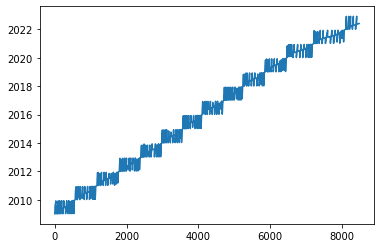

```python
# ..but which number is the month and which is the day?
# how can we check if what we just did makes sense?
pd.to_datetime(df["DateTimeOfCall"]).plot()
# should be a single monotonically increasing line: looks like days/months are mixed up
```

```python
# check the docs to see what options are available:
?pd.to_datetime
```

```python
# this looks better
pd.to_datetime(df["DateTimeOfCall"], dayfirst=True).head()
```

```
0   2009-01-01 03:01:00
1   2009-01-01 08:51:00
2   2009-01-04 10:07:00
3   2009-01-05 12:27:00
4   2009-01-06 15:23:00
Name: DateTimeOfCall, dtype: datetime64[ns]
```

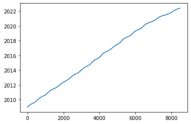

```python
# consistency check: plot datetime vs index, should increase monotonically
pd.to_datetime(df["DateTimeOfCall"], dayfirst=True).plot()
```

```python
# replace DateTimeOfCall column in dataframe with this one
df["DateTimeOfCall"] = pd.to_datetime(df["DateTimeOfCall"], dayfirst=True)
```

# Use the datetime as the index

```python
df.set_index("DateTimeOfCall", inplace=True)
```

```python
df
```

| DateTimeOfCall | IncidentNumber | CalYear | FinYear | TypeOfIncident | PumpCount | PumpHoursTotal | HourlyNotionalCost(£) | IncidentNotionalCost(£) | FinalDescription | AnimalGroupParent | ... | UPRN | Street | USRN | PostcodeDistrict | Easting_m | Northing_m | Easting_rounded | Northing_rounded | Latitude | Longitude |
| --- | --- | --- | --- | --- | --- | --- | --- | --- | --- | --- | --- | --- | --- | --- | --- | --- | --- | --- | --- | --- | --- |
| 2009-01-01 03:01:00 | 139091 | 2009 | 2008/09 | Special Service | 1.0 | 2.0 | 255 | 510.0 | Redacted | Dog | ... | NaN | Waddington Way | 20500146.0 | SE19 | NaN | NaN | 532350 | 170050 | NaN | NaN |
| 2009-01-01 08:51:00 | 275091 | 2009 | 2008/09 | Special Service | 1.0 | 1.0 | 255 | 255.0 | Redacted | Fox | ... | NaN | Grasmere Road | NaN | SE25 | 534785.0 | 167546.0 | 534750 | 167550 | 51.390954 | -0.064167 |
| 2009-01-04 10:07:00 | 2075091 | 2009 | 2008/09 | Special Service | 1.0 | 1.0 | 255 | 255.0 | Redacted | Dog | ... | NaN | Mill Lane | NaN | SM5 | 528041.0 | 164923.0 | 528050 | 164950 | 51.368941 | -0.161985 |
| 2009-01-05 12:27:00 | 2872091 | 2009 | 2008/09 | Special Service | 1.0 | 1.0 | 255 | 255.0 | Redacted | Horse | ... | 1.000000e+11 | Park Lane | 21401484.0 | UB9 | 504689.0 | 190685.0 | 504650 | 190650 | 51.605283 | -0.489684 |
| 2009-01-06 15:23:00 | 3553091 | 2009 | 2008/09 | Special Service | 1.0 | 1.0 | 255 | 255.0 | Redacted | Rabbit | ... | NaN | Swindon Lane | 21300122.0 | RM3 | NaN | NaN | 554650 | 192350 | NaN | NaN |
| ... | ... | ... | ... | ... | ... | ... | ... | ... | ... | ... | ... | ... | ... | ... | ... | ... | ... | ... | ... | ... | ... |
| 2022-05-31 06:18:00 | 077969-31052022 | 2022 | 2022/23 | Special Service | 1.0 | 1.0 | 364 | 364.0 | FOX STUCK IN NETTING IN FOOTBALL PITCH RSPCA ... | Fox | ... | 6.070003e+06 | SHELMERDINE CLOSE | 22701090.0 | E3 | 537134.0 | 181865.0 | 537150 | 181850 | 51.519074 | -0.024870 |
| 2022-05-31 10:55:00 | 078069-31052022 | 2022 | 2022/23 | Special Service | 1.0 | 1.0 | 364 | 364.0 | CAT TRAPPED ON ROOF | Cat | ... | NaN | SUN PASSAGE | 22503138.0 | SE16 | NaN | NaN | 534150 | 179350 | NaN | NaN |
| 2022-05-31 11:50:00 | 078094-31052022 | 2022 | 2022/23 | Special Service | 1.0 | 1.0 | 364 | 364.0 | BIRD TRAPPED ON ROOF RSPCA IN ATTENDANCE | Bird | ... | NaN | AMHERST DRIVE | 20300997.0 | BR5 | NaN | NaN | 545750 | 168250 | NaN | NaN |
| 2022-05-31 20:27:00 | 078340-31052022 | 2022 | 2022/23 | Special Service | 1.0 | 1.0 | 364 | 364.0 | CAT STUCK UP TREE- BEST ACCESS VIA HAMMOND CLOSE | Cat | ... | 1.205660e+07 | HAMMOND CLOSE | 20600812.0 | UB6 | 514798.0 | 185310.0 | 514750 | 185350 | 51.555015 | -0.345528 |
| 2022-05-31 20:35:00 | 078347-31052022 | 2022 | 2022/23 | Special Service | 1.0 | 1.0 | 364 | 364.0 | BIRD IMPALED BY WING - MEMBER OF PUBLIC WILL ... | Bird | ... | 2.000010e+11 | THE CHARTER ROAD | 22824000.0 | E4 | 539253.0 | 191894.0 | 539250 | 191850 | 51.608674 | 0.009612 |

8490 rows × 30 columns

```python
# can now use datetime to select rows: here is jan 2021
df.loc["2021-01-01":"2021-01-31", "FinalDescription"]
```

```
DateTimeOfCall
2021-01-01 12:09:00        KITTEN STUCK UP TREE  AL REQUESTED FROM SCENE
2021-01-01 14:06:00                                             Redacted
2021-01-03 18:40:00                CAT WITH LEG TRAPPED IN BATH PLUGHOLE
2021-01-04 13:39:00                                             Redacted
2021-01-06 10:22:00                                             Redacted
2021-01-06 13:09:00    CAT IN DISTRESS ON ROOF - ADDITIONAL APPLIANCE...
2021-01-06 20:35:00        DOG TRAPPED IN FOX HOLE  - MEET AT CLUB HOUSE
2021-01-07 23:50:00                   KITTEN STUCK BETWEEN WALL AND ROOF
2021-01-09 08:01:00                                  DOG STUCK IN TRENCH
2021-01-10 19:27:00                                             Redacted
2021-01-12 11:39:00                                             Redacted
2021-01-12 22:38:00                                 CAT TRAPPED IN DITCH
2021-01-16 18:05:00                          DOG TRAPPED IN PORTER CABIN
2021-01-17 16:09:00    DOG TRAPPED IN WAREHOUSE AREA - CALLER BELIEVE...
2021-01-17 17:09:00      BIRD TRAPPED IN NETTING    CALLER WILL MEET YOU
2021-01-18 15:17:00            CAT STUCK IN TREE BEING ATTACKED BY CROWS
2021-01-18 17:06:00    ASSIST RSPCA - SMALL ANIMAL RESUE - BIRD ENTAN...
2021-01-19 18:28:00                          CAT TRAPPED BEHIND CUPBOARD
2021-01-19 20:24:00                                             Redacted
2021-01-19 20:36:00                              RUNNING CALL AT ON ROOF
2021-01-20 09:35:00                      CAT STUCK BETWEEN TREE BRANCHES
2021-01-21 13:15:00                              SWAN TRAPPED IN NETTING
2021-01-21 18:23:00                               CAT TRAPPED IN CHIMNEY
2021-01-22 14:22:00                   CAT TRAPPED BETWEEN WALL AND FENCE
2021-01-23 10:18:00                               CAT TRAPPED IN CHIMNEY
2021-01-23 15:43:00                            CAT TRAPPED BETWEEN WALLS
2021-01-23 17:16:00                                             Redacted
2021-01-25 12:02:00             ASSIST RSPCA WITH FOX STUCK DOWN CULVERT
2021-01-26 13:42:00         DOG STUCK IN RAILINGS - CALLER WILL MEET YOU
2021-01-26 18:21:00                                             Redacted
2021-01-26 22:44:00    BIRDS TRAPPED IN BASKETBALL COURT CALLER IS ON...
2021-01-26 23:35:00             FOX TRAPPED IN FENCE IN ALLEYWAY NEXT TO
2021-01-27 09:18:00    CAT STUCK IN TREE - ATTENDED YESTERDAY AND ADV...
2021-01-27 10:12:00    BIRD TRAPPED BY LEG IN A TREE - RSPCA IN ATTEN...
2021-01-27 15:22:00                           CAT UP TREE   ASSIST RSPCA
2021-01-29 10:47:00                 TRAPPED FOX IN FENCE  IN REAR GARDEN
2021-01-30 14:53:00                                 CAT STUCK UNDER SHED
2021-01-30 15:28:00              BIRD CAUGHT IN NETTING - RSPCA ON SCENE
2021-01-30 17:54:00                                DOG TRAPPED UNDER CAR
2021-01-31 12:53:00                   CAT STUCK UP TREE - RSPCA ON SCENE
2021-01-31 13:48:00           INJURED CAT STUCK IN GREEN AREA AT REAR OF
Name: FinalDescription, dtype: object
```

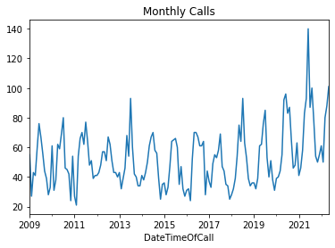

```python
# resample the timeseries by month and count incidents
df.resample("M")["IncidentNumber"].count().plot(title="Monthly Calls")
# see https://pandas.pydata.org/docs/user_guide/timeseries.html#timeseries-offset-aliases
plt.show()
```

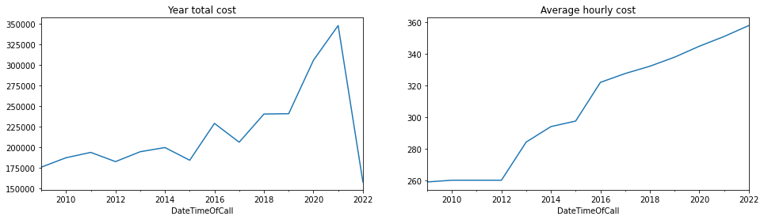

```python
# resample by year, sum total costs, average hourly costs
fig, axs = plt.subplots(figsize=(16, 4), ncols=2)
df.resample("Y")["IncidentNotionalCost(£)"].sum().plot(
    title="Year total cost", ax=axs[0]
)
df.resample("Y")["HourlyNotionalCost(£)"].mean().plot(
    title="Average hourly cost", ax=axs[1]
)
plt.show()
```